[figure not shown]

# Using Jupyter

## Markdown cells

This is a Markdown (documentation) cell, for adding documentation and comments to a notebook. It uses Markdown, a text styling language, as well as HTML. When a Markdown cell is "run", it converts the contents of the cell into HTML, which is then rendered and displayed.

Double-click on a Markdown cell to see its source.

This is **more** *markdown*. Surround text with double asterisk for bold, or single underline for italic.

See the Notebook named **JupyterMarkdownGuide** for details.

## Code Cells

Code cells contain Python (or other language) code. When a code cell is run, it executes the code, and shows the output below the cell. The output is retained unless you explicitly clear it.

```python
x = 3
for i in range(3):
    print(i)
```

```
0
1
2
```

```python
print("wombat")
```

```
wombat
```

Why can't you say *insert markdown cell ...*??

## It's all one program

All code is run in the same instance of the Python interpreter, so that objects created in one cell are available to other cells, as long as the first cell has been run.

```python
from datetime import date as Date
```

```python
then = Date(2011,5,22)
```

```python
print(then.year)
```

[output not shown]

```python
%pinfo then
```

## Getting help

Putting a ? before (or after) any object displays help for that object. Using ?? will add more detailed help, if available. (The output will be in a separate pane at the bottom of the browser window).

```python
i?
```

```python
Date??
```

## Using Python's scientific libraries

For typical use of Python's scientific libraries, put the following at the top of the notebook in a code cell:

```
import pandas as pd
import numpy as np
import matplotlib.pyplot as plt
```

Other modules and packages should be included as needed.

```python
import pandas as pd
import numpy as np
import matplotlib.pyplot as plt
%matplotlib inline
```

## Inline plotting

After matplotlib is imported, use the **%matplotlib inline** magic to display figures as part of the notebook. Otherwise, they are displayed in popup windows.

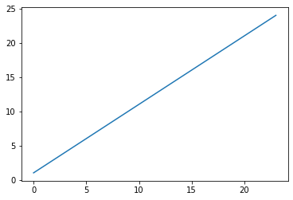

```python
plt.plot(np.arange(1,25))
```

## Using HTML

Since Markdown is converted to HTML, any actual HTML in a Markdown cell is used.

- red
- purple
- orange

## Magics

iPython and Jupyter notebooks have *line magics*, which are line-oriented. Many of them execute commands or turn iPython settings on and off.

Jupyter has *cell magics*, which apply to the entire cell.

```python
%lsmagic
```

```
Available line magics:
%alias  %alias_magic  %autoawait  %autocall  %automagic  %autosave  %bookmark  %cat  %cd  %clear  %colors  %conda  %config  %connect_info  %cp  %debug  %dhist  %dirs  %doctest_mode  %ed  %edit  %env  %gui  %hist  %history  %killbgscripts  %ldir  %less  %lf  %lk  %ll  %load  %load_ext  %loadpy  %logo…

Available cell magics:
%%!  %%HTML  %%SVG  %%bash  %%capture  %%debug  %%file  %%html  %%javascript  %%js  %%latex  %%markdown  %%perl  %%prun  %%pypy  %%python  %%python2  %%python3  %%ruby  %%script  %%sh  %%svg  %%sx  %%system  %%time  %%timeit  %%writefile

Automagic is ON, % prefix IS NOT needed for line magics.
```

```python
!hostname
h = !hostname
print(h)
```

```
Johns-Macbook.attlocal.net
['Johns-Macbook.attlocal.net']
```

## Running external Python scripts

Use the **%run** magic to launch an external Python script

```python
%run ../EXAMPLES/my_vars.py
```

```python
print(user_name)
print(animal)
print(snake)
```

[output not shown]

## Loading scripts into cells

Use the **%load** magic to read a separate Python script into the current cell. After it's loaded, it can be run like any other cell.

Once the code is loaded into the cell, the **%load** command is commented out

```python
# %load ../EXAMPLES/read_tyger.py
#!/usr/bin/env python

with open("../DATA/tyger.txt", "r") as tyger_in:  # <1>
    for line in tyger_in:  # <2>
        print(line, end='')  # <3>
```

[output not shown]

## Using LaTeX

Markdown cells can render LaTeX via MathJax. Put the LaTeX code inside a pair of dollar signs: **\$\rho\$:**

$\rho$, $\rho$, $\rho$ your boat

$\mathbf{V}_1 \times \mathbf{V}_2 = \begin{vmatrix} \ \mathbf{i} & \mathbf{j} & \mathbf{k} \\ \frac{\partial X}{\partial u} & \frac{\partial Y}{\partial u} & 0\\ \frac{\partial X}{\partial v} & \frac{\partial Y}{\partial v} & 0\\ \end{vmatrix}$

$\left( \sum_{k=1}^n a_k b_k \right)^2 \leq \left( \sum_{k=1}^n a_k^2 \right) \left( \sum_{k=1}^n b_k^2 \right)$

### Can you read this limerick?

$\frac{12 + 144 + 20 + 3\sqrt{4}}{7} + (5 * 11) = 9^2 + 0$

*See text of limerick at the bottom of this notebook*

## Benchmarking

The **%%timeit** cell magic will execute the code in the cell and report the average time it took to execute it.

```python
fruits = ["pomegranate", "cherry", "apricot", "date", "Apple",
"lemon", "Kiwi", "ORANGE", "lime", "Watermelon", "guava",
"Papaya", "FIG", "pear", "banana", "Tamarind", "Persimmon",
"elderberry", "peach", "BLUEberry", "lychee", "GRAPE" ]
```

#### Benchmark with *for* loop

```python
%%timeit
f1 = []
for f in fruits:
    f1.append(f[:3])
```

```
2.81 µs ± 22.2 ns per loop (mean ± std. dev. of 7 runs, 100000 loops each)
```

#### Benchmark with list comprehension

```python
%%timeit
f2 = [f[:3] for f in fruits]
```

```
1.85 µs ± 25 ns per loop (mean ± std. dev. of 7 runs, 1000000 loops each)
```

## Images

You can insert images into doc cells using the Markdown image tag:

*The following uses a Markdown table to arrange the images.*

[output not shown]

### The limerick

A dozen, a gross, and a score  
Plus three times the square root of four  
Divided by seven  
Plus five times eleven  
Is nine squared and not a bit more.